# Introduction to statistics

version November 01, 2018

## Learning objectives

- Identify and distinguish between a population and a sample, and between parameters and statistics
- Identify the assumptions of the *t*-test
- Define “p-value” and interpret its meaning for a *t*-test
- Explain how population distribution and sample size influence the sampling distribution of the sample mean

## Statistical terminology

- Specimen
- Sample
- Population
- Statistic
- Parameter
- Statistical test
- Null hypothesis
- P-value
- Significance

## Specimen vs. Sample vs. Population

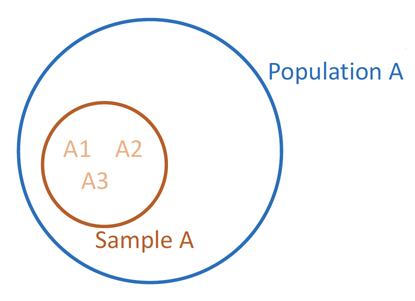

- Specimens A1, A2, A3, etc. taken from
- Sample A, which is taken from
- Population A
- Common language "sample" for 1 biological replicate = Specimen
- \(\neq\) Statistical meaning of "sample"

## Statistic vs. Parameter

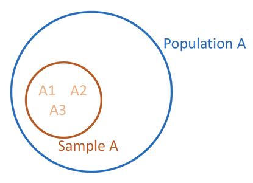

- Use a sample to calculate statistics
- **Statistics** estimate **parameters** of the overall population
- In real world systems, we can never truly measure a parameter
- **Statistic**: Mean weight of 10 beavers (sample) measured in BC
- **Parameter**: Mean weight of beavers in BC (population) including all individuals residing here

## Using statistics

- Use statistics of samples to draw conclusions about underlying populations
- Compare statistics of samples from different populations in **statistical tests**
- *t*-test, ANOVA, linear model, etc.

## *t*-test

- Compares 2 sample means
- Null hypothesis H<sub>0</sub>: the two population means are equal
- Alternate hypothesis H<sub>1</sub>: the two population means are not equal
- Hypotheses are about the underlying **populations** even though we only have data from samples
- The alternate says *nothing* about greater than / less than

## *t*-test assumptions

1. Simple random sample
2. Approximately normal distributions of sample means
3. Reasonably large sample size
4. Equal sample sizes*
5. Equal sample variances*

\(*\) Different equations exist if these are not true

## *t*-test equation

Assumes unequal variance

\[t = \frac{\bar x_1 -\bar x_2}{\sqrt(\frac{s_1^2}{n_1} + \frac{s_2^2}{n_2})}\]

- numerator = difference in sample means
- denominator = measure of sample variance in standard deviation (s) relative to the sample size (n)

## Why mean AND variance matter

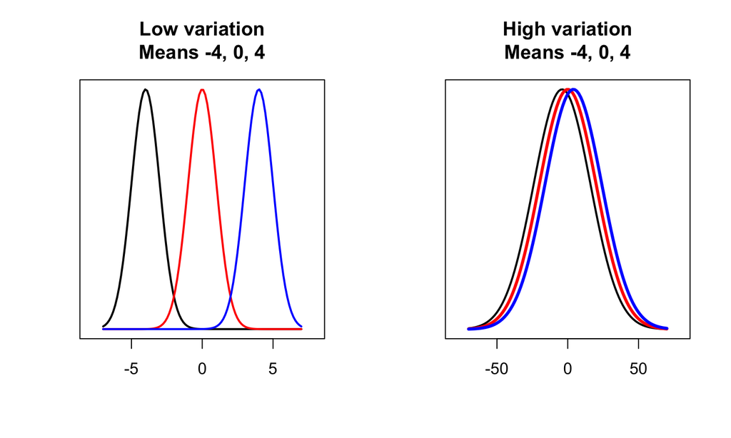

## Data for a *t*-test in R

```r
dat.ttest
```

```
## # A tibble: 6 x 4
##   Cruise Date       Depth_m O2_uM
##    <int> <date>       <dbl> <dbl>
## 1     18 2008-02-13      10 225.
## 2     18 2008-02-13     100  99.8
## 3     30 2009-02-11      10 180.
## 4     30 2009-02-11     100 132.
## 5     42 2010-02-10      10 182.
## 6     42 2010-02-10     100  54.7
```

## Data for a *t*-test in R

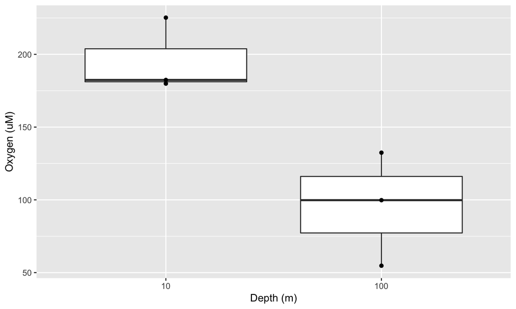

## *t*-test results

```r
t.test(O2_uM ~ as.factor(Depth_m), data = dat.ttest, var.equal=FALSE)
```

```
##
##  Welch Two Sample t-test
##
## data:  O2_uM by as.factor(Depth_m)
## t = 3.7243, df = 3.4441, p-value = 0.02656
## alternative hypothesis: true difference in means is not equal to 0
## 95 percent confidence interval:
##   20.49653 179.89413
## sample estimates:
##  mean in group 10 mean in group 100
##          195.8453           95.6500
```

## The *p*-value

- Probability value
- Measure of significance
- Probability that the difference in means would be \(\geq\) the observed results if the true population means are not different (H<sub>0</sub>)
- Probabilty of a false positive
- Probability that you conclude that the population means are different when they're actually not

## Levels of significance

### *p* < 0.05

- Common across multiple fields
- Up to 5% probability of a false positive
- Are you comfortable with *p* < 0.05 to test if a probiotic is associated with:
- gut microbiota composition?
- incidence of gastrointestinal disease?
- a serious adverse side effect?

## Defining the level of significance

- Based on research question and data types
- Must be done prior to running statistical tests
- Avoid *p* hacking!
- Don't change the *p* cutoff to fit your observed results
- Don't repeat or alter statistical tests with the goal of obtaining a significant result

## What if *p* = 0?

- Results due to rounding error
- Does not mean you are 100% confident that the population means are truly different
- Should be reported as *p* < the minimum value that the program will report, like *p* < 2E-16 for R

## Factors influencing the sample mean

[Online tutorial](http://www.zoology.ubc.ca/~whitlock/Kingfisher/CLT.htm)